# RIDGE y LASSO en R

# 1. Introducción

- Vimos que las técnicas de RIDGE y LASSO son extensiones del modelo de regresión lineal
- Intentan resolver los problemas de alta dimensionalidad
- Tener muchos atributos, respecto al número de observaciones, genera problemas
- Alta varianza en las predicciones
- Dificultad en la interpretabilidad de los modelos
- RIDGE y LASSO introducen una penalidad en el tamaño de los coeficientes
- Halándolos hacia 0.
- Bajo RIDGE los coeficientes tenderán a 0 conforme se le de más peso a dicha penalidad. Pero nunca serán exactamente 0
- Bajo LASSO los coeficientes sí se convertirán en 0
- La clave está en la elección del parámetro lambda, que mide el peso dado a la penalidad en cada modelo

# 2. Datos

- Trabajaremos con datos de beisbolistas en USA
- La base `Hitters.csv` contiene información sobre el salario de un conjunto de beisbolistas
- Y queremos predecir el salario en función de ciertas características de estos peloteros
- Como siempre, establezcan en primer lugar el directorio de trabajo
- Luego, leamos la base como un data frame:

```r
hitters <- read.csv("Hitters.csv")
```

- Inspeccionemos la base:

```r
str(hitters)
```

```
## 'data.frame':    322 obs. of  21 variables:
##  $ X        : Factor w/ 322 levels "-Al Newman","-Alan Ashby",..: 12 2 7 8 10 6 1 14 11 9 ...
##  $ AtBat    : int  293 315 479 496 321 594 185 298 323 401 ...
##  $ Hits     : int  66 81 130 141 87 169 37 73 81 92 ...
##  $ HmRun    : int  1 7 18 20 10 4 1 0 6 17 ...
##  $ Runs     : int  30 24 66 65 39 74 23 24 26 49 ...
##  $ RBI      : int  29 38 72 78 42 51 8 24 32 66 ...
##  $ Walks    : int  14 39 76 37 30 35 21 7 8 65 ...
##  $ Years    : int  1 14 3 11 2 11 2 3 2 13 ...
##  $ CAtBat   : int  293 3449 1624 5628 396 4408 214 509 341 5206 ...
##  $ CHits    : int  66 835 457 1575 101 1133 42 108 86 1332 ...
##  $ CHmRun   : int  1 69 63 225 12 19 1 0 6 253 ...
##  $ CRuns    : int  30 321 224 828 48 501 30 41 32 784 ...
##  $ CRBI     : int  29 414 266 838 46 336 9 37 34 890 ...
##  $ CWalks   : int  14 375 263 354 33 194 24 12 8 866 ...
##  $ League   : Factor w/ 2 levels "A","N": 1 2 1 2 2 1 2 1 2 1 ...
##  $ Division : Factor w/ 2 levels "E","W": 1 2 2 1 1 2 1 2 2 1 ...
##  $ PutOuts  : int  446 632 880 200 805 282 76 121 143 0 ...
##  $ Assists  : int  33 43 82 11 40 421 127 283 290 0 ...
##  $ Errors   : int  20 10 14 3 4 25 7 9 19 0 ...
##  $ Salary   : num  NA 475 480 500 91.5 750 70 100 75 1100 ...
##  $ NewLeague: Factor w/ 2 levels "A","N": 1 2 1 2 2 1 1 1 2 1 ...
```

- La primera variable es la de nombres. No nos interesa

```r
hitters <- hitters[, -1]
```

- Nos interesa predecir el salario:

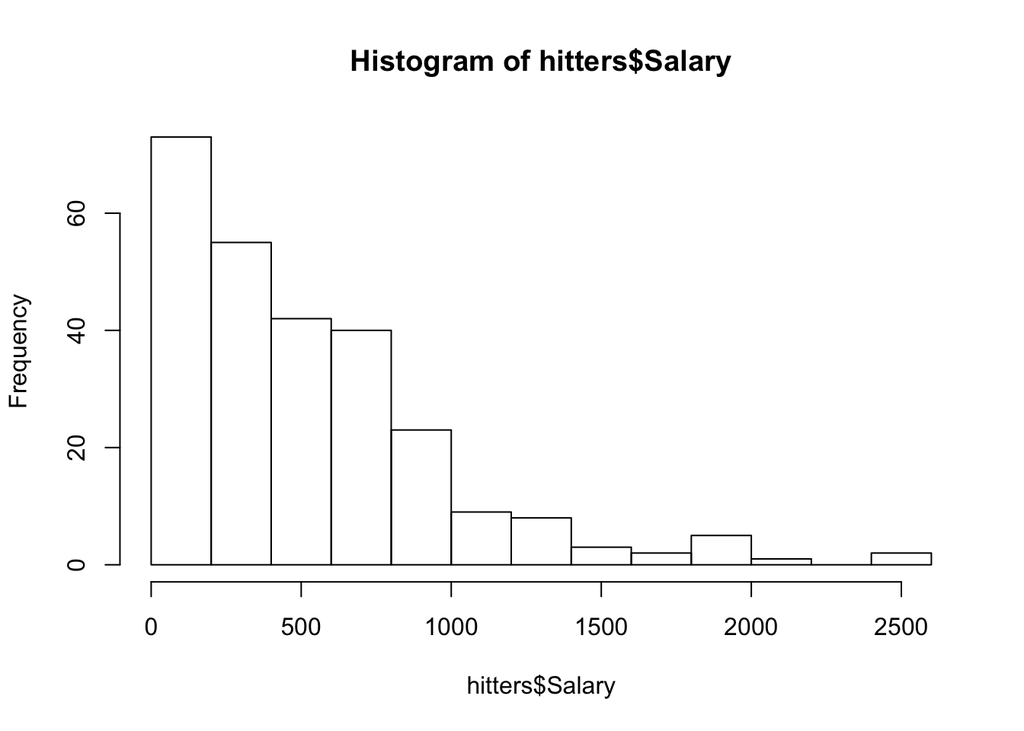

```r
hist(hitters$Salary)
```

- Nótese que esta base tiene algunos missing values en Salary

```r
sum(is.na(hitters$Salary))
```

```
## [1] 59
```

- 59 observaciones en total
- Para implementar RIDGE y LASSO, debemos deshacernos de estas observaciones

```r
hitters=na.omit(hitters)
```

- Verifiquemos:

```r
sum(is.na(hitters))
```

```
## [1] 0
```

```r
str(hitters)
```

```
## 'data.frame':    263 obs. of  20 variables:
##  $ AtBat    : int  315 479 496 321 594 185 298 323 401 574 ...
##  $ Hits     : int  81 130 141 87 169 37 73 81 92 159 ...
##  $ HmRun    : int  7 18 20 10 4 1 0 6 17 21 ...
##  $ Runs     : int  24 66 65 39 74 23 24 26 49 107 ...
##  $ RBI      : int  38 72 78 42 51 8 24 32 66 75 ...
##  $ Walks    : int  39 76 37 30 35 21 7 8 65 59 ...
##  $ Years    : int  14 3 11 2 11 2 3 2 13 10 ...
##  $ CAtBat   : int  3449 1624 5628 396 4408 214 509 341 5206 4631 ...
##  $ CHits    : int  835 457 1575 101 1133 42 108 86 1332 1300 ...
##  $ CHmRun   : int  69 63 225 12 19 1 0 6 253 90 ...
##  $ CRuns    : int  321 224 828 48 501 30 41 32 784 702 ...
##  $ CRBI     : int  414 266 838 46 336 9 37 34 890 504 ...
##  $ CWalks   : int  375 263 354 33 194 24 12 8 866 488 ...
##  $ League   : Factor w/ 2 levels "A","N": 2 1 2 2 1 2 1 2 1 1 ...
##  $ Division : Factor w/ 2 levels "E","W": 2 2 1 1 2 1 2 2 1 1 ...
##  $ PutOuts  : int  632 880 200 805 282 76 121 143 0 238 ...
##  $ Assists  : int  43 82 11 40 421 127 283 290 0 445 ...
##  $ Errors   : int  10 14 3 4 25 7 9 19 0 22 ...
##  $ Salary   : num  475 480 500 91.5 750 ...
##  $ NewLeague: Factor w/ 2 levels "A","N": 2 1 2 2 1 1 1 2 1 1 ...
##  - attr(*, "na.action")=Class 'omit'  Named int [1:59] 1 16 19 23 31 33 37 39 40 42 ...
##   .. ..- attr(*, "names")= chr [1:59] "1" "16" "19" "23" ...
```

- Quedamos con 263 observaciones. En la práctica, esto es lo que se hace con el enfoque tradicional OLS
- Eliminar las observaciones que tienen algún missing
- Para correr regresiones RIDGE y LASSO, necesitamos el paquete `glmnet`. Si no lo han hecho, ejecuten `install.packages("glmnet")`
- Y carguémoslo:

```r
library(glmnet)
```

- La sintaxis de este paquete es diferente a la de otros.
- Debemos definir la matriz de atributos con la función `model.matrix()` y luego el vector de outcomes

```r
x <- model.matrix(Salary ~ ., hitters)[, -1]
```

```r
y <- hitters$Salary
```

# 3. Regresión RIDGE

- En la función `glmnet()` del paquete el parámetro alpha define el modelo a usar, entre RIDGE y LASSO
- alpha=0 para RIDGE y alpha=1 para LASSO
- A su vez, debemos definir el rango de valores de lambda para el cual queremos estimar modelos
- La idea es ir desde lambdas cercanos a 0 (OLS) hasta valores muy grandes (modelo sin predictores)
- Creemos una grilla de 100 lambdas, arrancando en 0.01 hasta 10,000,000,000

```r
grid=10^seq(10,-2,length=100)
```

- Ahora sí, podemos estimar los modelos

```r
hitters_ridge <- glmnet(x, y, alpha=0, lambda=grid)
```

- Se corrieron 100 modelos, uno para cada lambda
- Cada uno genera distintos coeficientes para las variables
- Dichos coeficientes deben ir disminuyendo a medida que lambda crece
- Podemos comparar, por ejemplo, los coeficientes del lambda 50 con los del 60
- Al crecer el número en realidad desciende lambda, por como definimos la grilla
- Veamos quién es cada lambda

```r
hitters_ridge$lambda[50]
```

```
## [1] 11497.57
```

```r
hitters_ridge$lambda[60]
```

```
## [1] 705.4802
```

- Y ahora veamos los coeficiente de cada lambda

```r
coef(hitters_ridge)[,50]
```

```
##   (Intercept)         AtBat          Hits         HmRun          Runs
## 407.356050200   0.036957182   0.138180344   0.524629976   0.230701523
##           RBI         Walks         Years        CAtBat         CHits
##   0.239841459   0.289618741   1.107702929   0.003131815   0.011653637
##        CHmRun         CRuns          CRBI        CWalks       LeagueN
##   0.087545670   0.023379882   0.024138320   0.025015421   0.085028114
##     DivisionW       PutOuts       Assists        Errors    NewLeagueN
##  -6.215440973   0.016482577   0.002612988  -0.020502690   0.301433531
```

```r
coef(hitters_ridge)[,60]
```

```
##  (Intercept)        AtBat         Hits        HmRun         Runs
##  54.32519950   0.11211115   0.65622409   1.17980910   0.93769713
##          RBI        Walks        Years       CAtBat        CHits
##   0.84718546   1.31987948   2.59640425   0.01083413   0.04674557
##       CHmRun        CRuns         CRBI       CWalks      LeagueN
##   0.33777318   0.09355528   0.09780402   0.07189612  13.68370191
##    DivisionW      PutOuts      Assists       Errors   NewLeagueN
## -54.65877750   0.11852289   0.01606037  -0.70358655   8.61181213
```

- Claramente, a medida que lambda disminuye, los coeficientes son más grandes
- De hecho, podemos recuperar los coeficientes de cualquier lambda con la función predict
- Por ejemplo, los de lambda=0 (caso OLS)

```r
predict(hitters_ridge,s=0,type="coefficients")[1:20,]
```

```
##   (Intercept)         AtBat          Hits         HmRun          Runs
##  164.11321606   -1.97386151    7.37772270    3.93660219   -2.19873625
##           RBI         Walks         Years        CAtBat         CHits
##   -0.91623008    6.20037718   -3.71403424   -0.17510063    0.21132772
##        CHmRun         CRuns          CRBI        CWalks       LeagueN
##    0.05629004    1.36605490    0.70965516   -0.79582173   63.40493257
##     DivisionW       PutOuts       Assists        Errors    NewLeagueN
## -117.08243713    0.28202541    0.37318482   -3.42400281  -25.99081928
```

- Para entrenar y poner a prueba el modelo dividimos la base en dos: entrenamiento y prueba:

```r
set.seed (123)
train=sample(1:nrow(x), nrow(x)/2)
test=(-train)
y_test=y[test]
```

```r
hitters_ridge=glmnet(x[train ,],y[train],alpha=0,lambda=grid)
```

- Se estimaron 100 modelos, uno para cada lambda, que pueden verse gráficamente

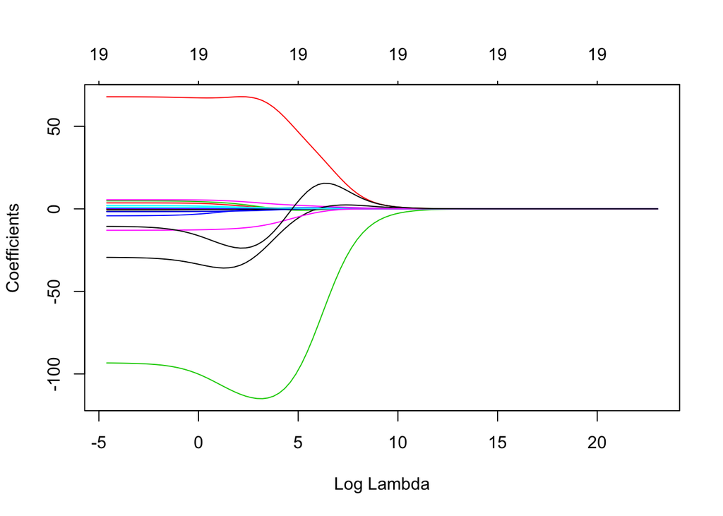

```r
plot(hitters_ridge, xvar="lambda")
```

- A medida que lambda crece, los coeficientes decrecen y tienden a cero
- Ahora tenemos que determinar cuál es el lambda óptimo
- Para esto usamos técnicas de validación cruzada con la función `cv.glmnet`

```r
set.seed(123)
cv_ridge <- cv.glmnet(x[train, ], y[train], alpha=0)
```

- Acá ya determinamos cuál es el lambda óptimo
- Podemos saberlo

```r
bestlam <- cv_ridge$lambda.min
bestlam
```

```
## [1] 507.9526
```

- El lambda óptimo es 507.9526
- Por tanto, el modelo es:

```r
predict(cv_ridge,s=bestlam,type="coefficients")[1:20,]
```

```
##  (Intercept)        AtBat         Hits        HmRun         Runs
## 139.16053313   0.03400628   0.36735837  -0.43860902   0.59052973
##          RBI        Walks        Years       CAtBat        CHits
##   0.28761066   1.48878796   0.92457493   0.01392852   0.06415854
##       CHmRun        CRuns         CRBI       CWalks      LeagueN
##   0.05935688   0.12628830   0.08441978   0.09699793  30.33225652
##    DivisionW      PutOuts      Assists       Errors   NewLeagueN
## -62.90818147   0.18488629   0.14021560  -1.59087780  15.43144939
```

# 4. LASSO

- El proceso es equivalente para el modelo LASSO
- La diferencia es que se fija el parámetro alpha=1
- Estimemos el modelo en la base de entrenamiento:

```r
hitters_lasso=glmnet(x[train ,],y[train],alpha=1,lambda=grid)
```

- Nuevamente, se estimaron 100 modelos
- Los podemos ver gráficamente:

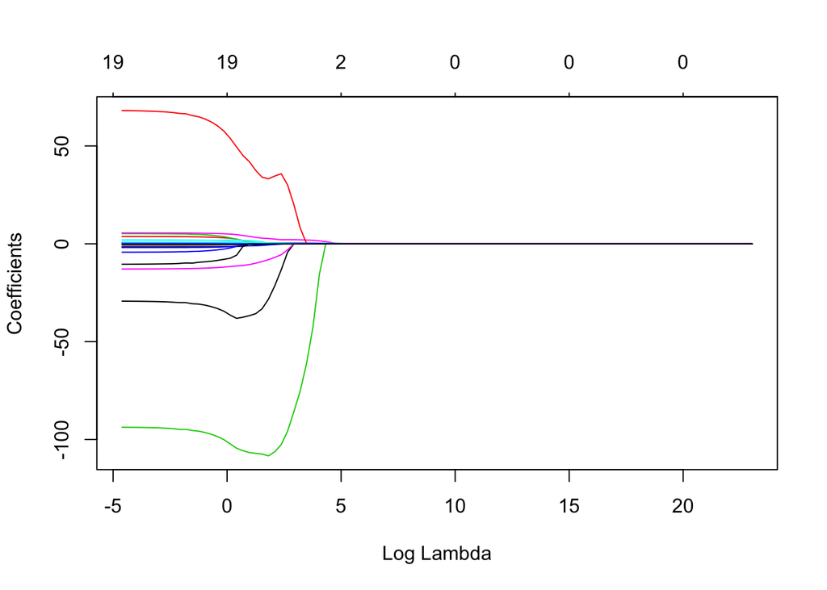

```r
plot(hitters_lasso, xvar="lambda")
```

- A medida que lambda crece, los coeficientes caen y se vuelven 0
- Averiguemos cuál es el lambda óptimo

```r
set.seed(123)
cv_lasso=cv.glmnet(x[train ,],y[train],alpha=1)
```

- Determinemos el lambda óptimo

```r
bestlam=cv_lasso$lambda.min
bestlam
```

```
## [1] 27.74578
```

- Y estimemos el modelo asociado

```r
predict(cv_lasso,s=bestlam,type="coefficients")[1:20,]
```

```
## (Intercept)       AtBat        Hits       HmRun        Runs         RBI
## 159.8418383   0.0000000   0.0000000   0.0000000   0.0000000   0.0000000
##       Walks       Years      CAtBat       CHits      CHmRun       CRuns
##   1.9724434   0.0000000   0.0000000   0.1060819   0.0000000   0.3812221
##        CRBI      CWalks     LeagueN   DivisionW     PutOuts     Assists
##   0.0000000   0.0000000   2.0427131 -69.7693890   0.3346266   0.1284641
##      Errors  NewLeagueN
##   0.0000000   0.0000000
```